# Lab 17

## Weather in NYC

The dataset for this practice exam consists of a single year of observed weather data from New York City. Read in the dataset with this command:

```r
weather <- read_csv("https://statsmaths.github.io/stat_data/weather-nyc.csv")
```

Here is a data dictionary for the variables:

- **date**: the date of the weather record, formatted YYYY-MM-DD
- **actual_mean_temp**: the measured average temperature for that day (celsius)
- **actual_min_temp**: the measured minimum temperature for that day (celsius)
- **actual_max_temp**: the measured maximum temperature for that day (celsius)
- **average_min_temp**: the average minimum temperature on that day since 1880 (celsius)
- **average_max_temp**: the average maximum temperature on that day since 1880 (celsius)
- **record_min_temp**: the lowest ever temperature on that day since 1880 (celsius)
- **record_max_temp**: the highest ever temperature on that day since 1880 (celsius)
- **record_min_temp_year**: the year that the lowest ever temperature occurred
- **record_max_temp_year**: the year that the highest ever temperature occurred
- **actual_precipitation**: the measured amount of rain or snow for that day (cm)
- **average_precipitation**: the average amount of rain or snow on that day since 1880 (cm)
- **record_precipitation**: the highest amount of rain or snow on that day since 1880 (cm)

If other questions about what these variables mean arise, please let me know.

## 1. A straightforward line plot

In the first plot, create a line plot (i.e., use `geom_line`) with date on the x-axis and the actual maximum tempurature on the y-axis. Make sure that you label the two axes. Otherwise, you can leave everything else equal to the defaults.

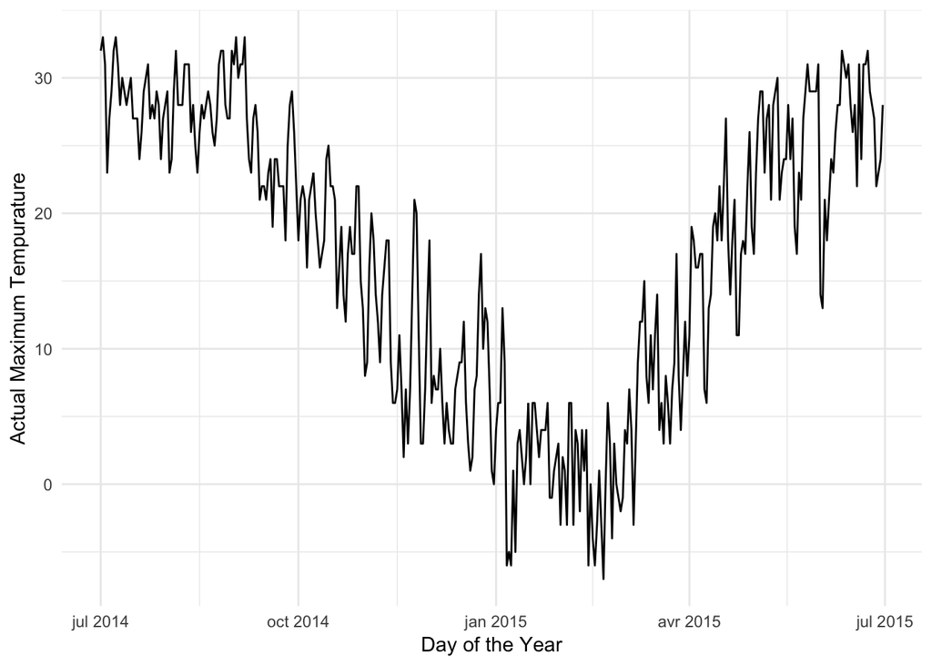

```r
ggplot(weather, aes(date, actual_max_temp)) +
  geom_line() +
  xlab("Day of the Year") +
  ylab("Actual Maximum Tempurature")
```

## 2. Two lines on one plot with colors

In the second plot, layer two line geometries that show the actual minimum tempurature and the actual maximum tempurature. Date is still on the x-axis. Further, color the minimum tempurature with the color “#5be5e5” (it’s a pretty shade of blue) and the maximum tempurature with the color “#ff6666” (a pretty shade of red). Don’t forget to include labels for the axes; you do not need to add manual labels for the two curves (it should be relatively obvious what they are showing).

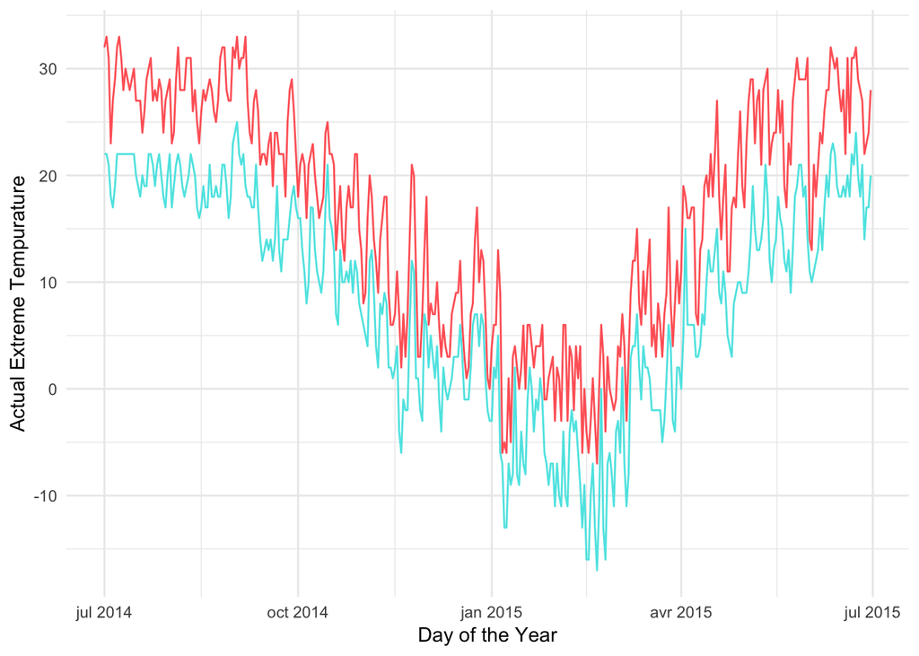

```r
ggplot(weather, aes(date, actual_max_temp)) +
  geom_line(color = "#ff6666") +
  geom_line(aes(y = actual_min_temp), color = "#5be5e5") +
  xlab("Day of the Year") +
  ylab("Actual Extreme Tempurature")
```

## 3. Mapping aesthetics with variables

In this plot you are going to make use of a new geometry layer that you might not have seen, but you have all of the tools to work with it, called `geom_segment`. It creates a collection of short line segments and requires four aesthetics: the x and y aesthetics control where the segement begins, but you must also specify the xend and yend aesthetics to describe what variables determine where the segment ends. Think of these like the label aesthetic in geom_text; additional parameters that we have to specify to make the layer meaningful.

The plot should have data again on the x-axis, with a geom_segment layer with segements that start with a y-value of actual_max_temp and proceed down to the y-value of actual_min_temp. That is, each day will have a line going from the high temperature to the low tempurature. Further, the segements should be colored according to the actualy_mean_temp and you should add this layer:

- scale_color_continuous(low = “#5be5e5”, high =“#ff6666”)

To the plot to make the tempuratures show up on a nice-looking scale (cold tempuratures are blue and warm tempuratures are read).

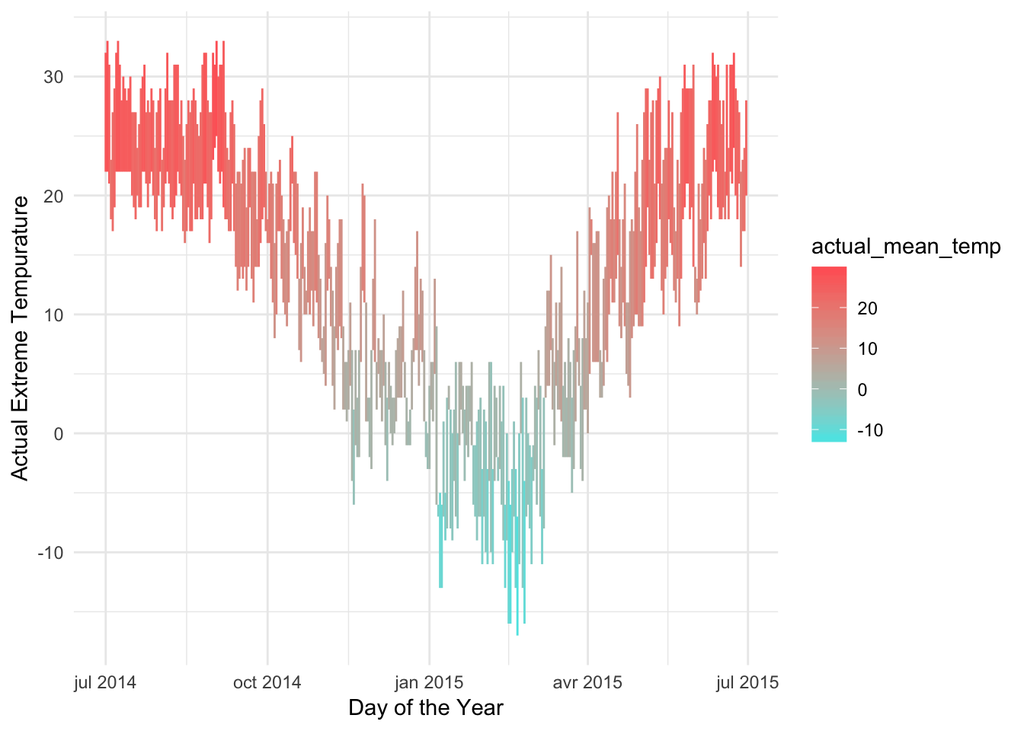

```r
ggplot(weather, aes(date, actual_max_temp)) +
  geom_segment(aes(xend=date, yend=actual_min_temp, color=actual_mean_temp)) +
  scale_color_continuous(low = "#5be5e5", high ="#ff6666") +
  xlab("Day of the Year") +
  ylab("Actual Extreme Tempurature")
```

## 4. Adding an Annotation to the Plot

On this plot, you will again create a line plot with the actual_max_temp on the y-axis and date on the x-axis. Additionally, display a red dot indicating the maximum tempurature on your birthday from this year. Note that the year starts on 1 July 2014 and ends on 30 June 2015, so you’ll label your 2014 birthday if you were born in the second half of the year and your 2015 birthday if born in the first half of the year.

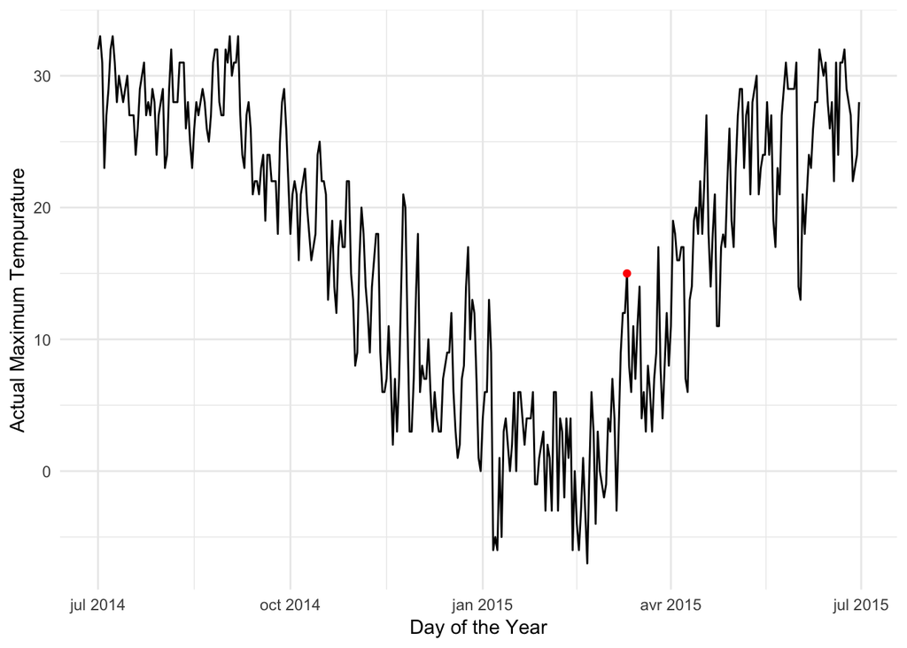

```r
ggplot(weather, aes(date, actual_max_temp)) +
  geom_line() +
  annotate("point", x=as.Date("2015-03-11"), y = 15, color = "red") +
  xlab("Day of the Year") +
  ylab("Actual Maximum Tempurature")
```

## 5. Filtering Data

In this final question, first create a new dataset named `rain` by filtering the weather dataset to those days that have an actual precipitation above zero (i.e., it rained or snowed on a given day).

```r
rain <- filter(weather, actual_precipitation > 0)
```

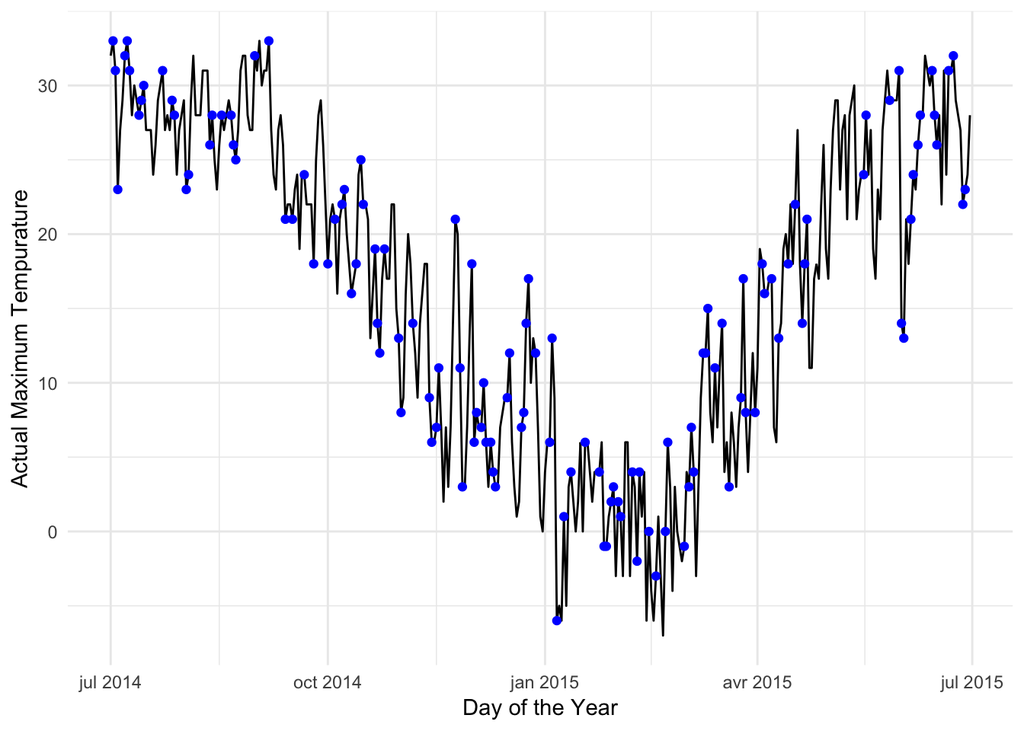

```r
ggplot(weather, aes(date, actual_max_temp)) +
  geom_line() +
  geom_point(color = "blue", data = rain) +
  xlab("Day of the Year") +
  ylab("Actual Maximum Tempurature")
```